# Impact of adult sex ratio on mating, dispersal, and survival in bush-crickets

- Show All Code
- Hide All Code
- View Source

Exploration of dataset

Authors

Affiliations

[Luke Eberhart-Hertel](https://www.bi.mpg.de/person/115852/2867)

Department of Ornithology, Max Planck Institute for Biological Intelligence, Seewiesen, Germany

Tuba Rizvi

Department of Evolutionary Biology, Bielefeld University, Germany

Martin Stoffel

Department of Evolutionary Biology, Bielefeld University, Germany

Karoline Fritzche

Institute of Biology, Albert Ludwig University, Freiburg, Germany

Jonothan Henshaw

Institute of Biology, Albert Ludwig University, Freiburg, Germany

Steve Ramm

Ecobio, Université de Rennes, Rennes, France

Klaus Reinhold

Department of Evolutionary Biology, Bielefeld University, Germany

Published

August 22, 2025

### Custom functions

```r
# scaled mass index calculation from Peig and Green (2009)
# https://doi.org/10.1111/j.1365-2435.2010.01751.x
scaledMassIndex <-
  function(x, y, x.0 = mean(x)) {
    logM.ols <- lm(log(y) ~ log(x))
    logM.rob <- rlm(log(y) ~ log(x), method = "M")
    b.msa.ols <- coef(sma(log(y) ~ log(x)))[2]
    b.msa.rob <- coef(sma(log(y) ~ log(x), robust = T))[2]
    SMI.ols <- y * (x.0 / x) ^ b.msa.ols
    SMI.rob <- y * (x.0 / x) ^ b.msa.rob
    res <- data.frame(SMI.ols, SMI.rob, x, y)
    pred.DT <-
      data.table(x = seq(min(x), max(x), length = 100)) %>%
      .[, y.ols := predict(logM.ols, newdata = .) %>% exp] %>%
      .[, y.rob := predict(logM.rob, newdata = .) %>% exp]
    attr(res, "b.msa") <- c(ols = b.msa.ols, rob = b.msa.rob)
    return(res)
  }
```

## Opportunity for sexual selection

#### data prepartation

```r
# import data
sexual_network_tuba <-
  read_excel("data/raw/ASR_metrics.xlsx",
             sheet = "sexual_network",
             col_types = "text") %>%
  arrange(cage, batch, ASR_treatment, day, male_ID, female_ID)

# tally the number of replicates
sexual_network_tuba %>%
  select(cage, batch, ASR_treatment) %>%
  distinct() %>%
  group_by(ASR_treatment, batch) %>%
  summarise(n_replicates = n())
```

```
# A tibble: 6 × 3
# Groups:   ASR_treatment [3]
  ASR_treatment batch n_replicates
  <chr>         <chr>        <int>
1 FB            1                7
2 FB            2                9
3 MB            1                5
4 MB            2                8
5 UB            1                9
6 UB            2                8
```

```r
# tally the max number of days for each cage
sexual_network_tuba %>%
  select(day, cage, batch, ASR_treatment) %>%
  distinct() %>%
  group_by(ASR_treatment, batch, cage) %>%
  summarise(max_day = max(day, na.rm = TRUE),
            min_day = min(day, na.rm = TRUE)) %>%
  select(cage, batch, ASR_treatment, min_day, max_day) %>%
  distinct() %>%
  arrange(cage, batch, ASR_treatment, min_day, max_day) %>%
  arrange(desc(max_day))
```

```
# A tibble: 46 × 5
# Groups:   ASR_treatment, batch [6]
   cage  batch ASR_treatment min_day max_day
   <chr> <chr> <chr>         <chr>   <chr>
 1 25    2     MB            1       7
 2 34    2     FB            1       7
 3 35    2     FB            2       7
 4 36    2     FB            1       7
 5 37    2     FB            1       7
 6 44    2     UB            1       7
 7 47    2     UB            1       7
 8 48    2     UB            1       7
 9 10    1     FB            1       6
10 16    1     FB            1       6
# ℹ 36 more rows
```

```r
# calculate sex-specific I_m for each cage
male_I_m_cage_long <-
  sexual_network_tuba %>%
  group_by(male_ID, cage, batch, ASR_treatment) %>%
  summarise(n_mates = n_distinct(female_ID)) %>%
  ungroup() %>%
  group_by(cage, batch, ASR_treatment) %>%
  summarise(min_n_mates = min(n_mates),
            max_n_mates = max(n_mates),
            mean_n_mates = mean(n_mates),
            var_I_m = ifelse(n() > 1, var(n_mates), 0),
            # var_I_m_ = var(n_mates),
            mean_I_m2 = mean_n_mates^2,
            I_m = var_I_m/mean_I_m2) %>% #,
            # I_m_ = var_I_m_/mean_I_m2) %>%
  mutate(sex = "M")

female_I_m_cage_long <-
  sexual_network_tuba %>%
  group_by(female_ID, cage, batch, ASR_treatment) %>%
  summarise(n_mates = n_distinct(male_ID)) %>%
  ungroup() %>%
  group_by(cage, batch, ASR_treatment) %>%
  summarise(min_n_mates = min(n_mates),
            max_n_mates = max(n_mates),
            mean_n_mates = mean(n_mates),
            var_I_m = ifelse(n() > 1, var(n_mates), 0),
            mean_I_m2 = mean_n_mates^2,
            I_m = var_I_m/mean_I_m2) %>%
  mutate(sex = "F")

# combine data and set classes
I_m_cage_long <-
  bind_rows(male_I_m_cage_long, female_I_m_cage_long) %>%
  mutate(mate_availabilty = ifelse((sex == "F" & ASR_treatment == "MB") | (sex == "M" & ASR_treatment == "FB"), "high",
                                   ifelse((sex == "F" & ASR_treatment == "FB") | (sex == "M" & ASR_treatment == "MB"), "low",
                                          "equal"))) %>%
  mutate(ASR_treatment = factor(ASR_treatment,
                                 levels = c("UB", "FB", "MB")),
         mate_availabilty = factor(mate_availabilty,
                                   levels = c("equal", "low", "high")),
         sex = factor(sex, levels = c("F", "M")),
         cage = factor(cage))
```

#### mate availability

##### 1. The Tweedie distribution fits our data’s structure

- **I_m** is continuous, non-negative, and skewed — not normally distributed.
- The Tweedie family handles this well, especially when there’s **a mix of small values and some zeros** without true zero inflation (confirmed by the DHARMa test).
- It accommodates a **variance–mean relationship** of the form *Var(y) ∝ μ^p*, which is common in ecological and behavioural count/variance measures.

##### 2. The log link is interpretable and stabilises variance

- The `link = "log"` models multiplicative (percentage) changes instead of additive ones.
- Coefficients can be exponentiated to give **ratios** between groups (e.g., effect of sex within high mate availability).
- It ensures predicted values are strictly positive, matching your biological measure (**I_m** can’t be negative).

##### 4. Flexibility for mixed effects

- `glmmTMB` lets you include the **random intercept for cage** easily, capturing repeated measures/non-independence.
- Alternative families like Gaussian or Poisson would either misrepresent the skew, fail at zero handling, or give poorer diagnostics.

```r
mod_tweedie_ma <- glmmTMB(
  I_m ~ sex * mate_availabilty + batch + (1 | cage),
  family = tweedie(link = "log"),
  data = I_m_cage_long
)
summary(mod_tweedie_ma)
```

```
 Family: tweedie  ( log )
Formula:          I_m ~ sex * mate_availabilty + batch + (1 | cage)
Data: I_m_cage_long

      AIC       BIC    logLik -2*log(L)  df.resid
     36.0      61.2      -8.0      16.0        82

Random effects:

Conditional model:
 Groups Name        Variance Std.Dev.
 cage   (Intercept) 0.03979  0.1995
Number of obs: 92, groups:  cage, 45

Dispersion parameter for tweedie family (): 0.228

Conditional model:
                          Estimate Std. Error z value Pr(>|z|)
(Intercept)               -2.21034    0.35776  -6.178 6.48e-10 ***
sexM                      -0.05276    0.44567  -0.118   0.9058
mate_availabiltylow       -0.44469    0.50601  -0.879   0.3795
mate_availabiltyhigh      -0.39729    0.53245  -0.746   0.4556
batch2                     0.19928    0.28901   0.690   0.4905
sexM:mate_availabiltylow  -0.89450    0.90261  -0.991   0.3217
sexM:mate_availabiltyhigh  1.10526    0.66171   1.670   0.0949 .
---
Signif. codes:  0 '***' 0.001 '**' 0.01 '*' 0.05 '.' 0.1 ' ' 1
```

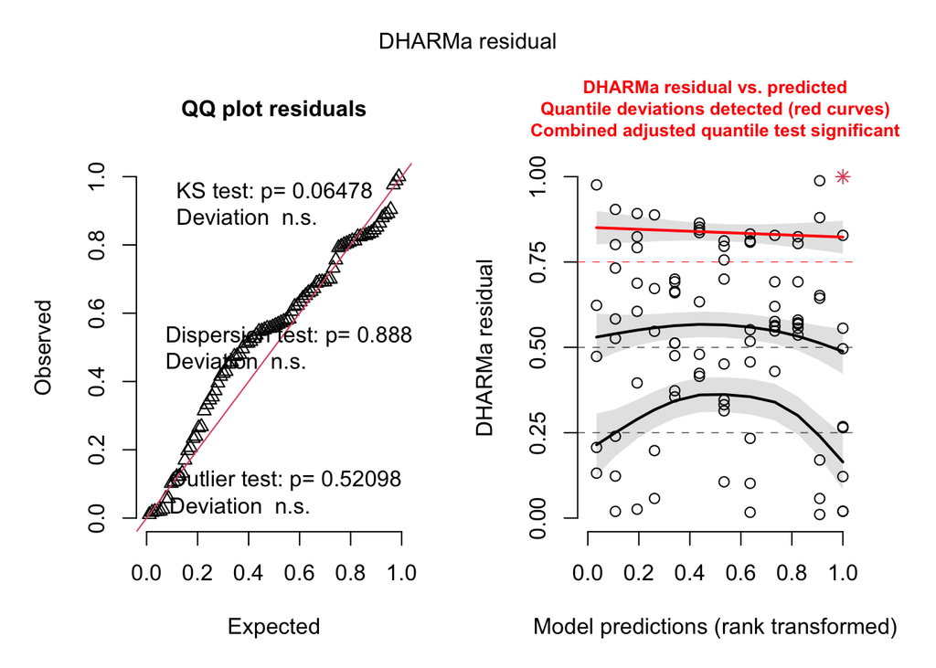

```r
sim_res <- simulateResiduals(mod_tweedie_ma)
plot(sim_res)
```

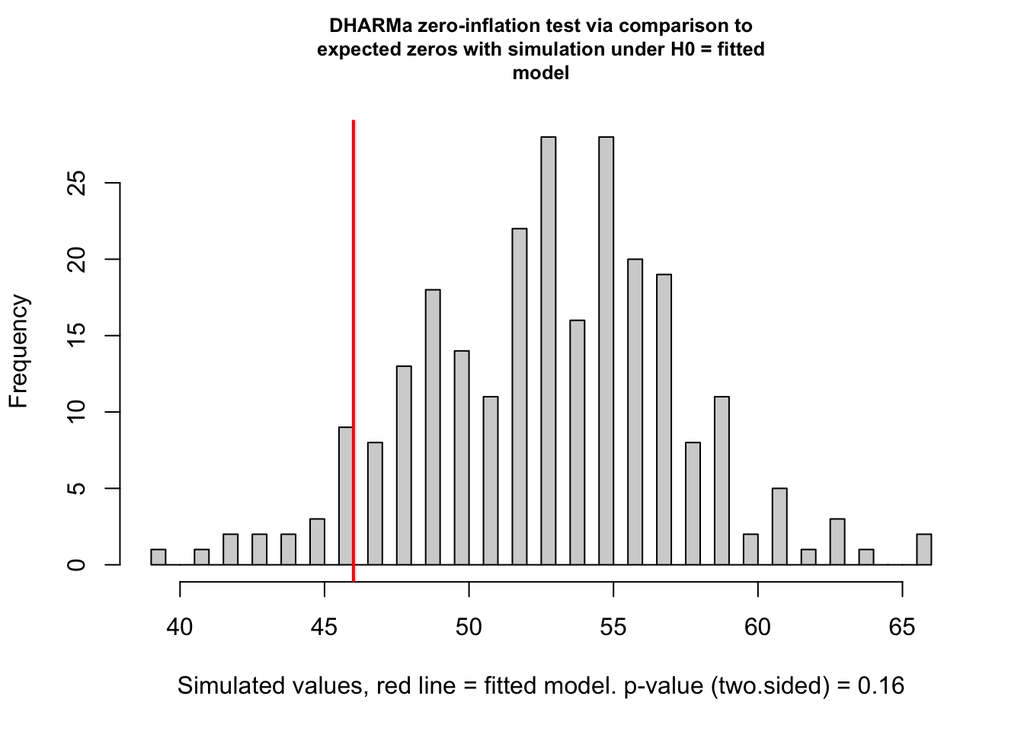

```
    DHARMa zero-inflation test via comparison to expected zeros with
    simulation under H0 = fitted model

data:  simulationOutput
ratioObsSim = 0.86792, p-value = 0.16
alternative hypothesis: two.sided
```

```r
testZeroInflation(sim_res)
```

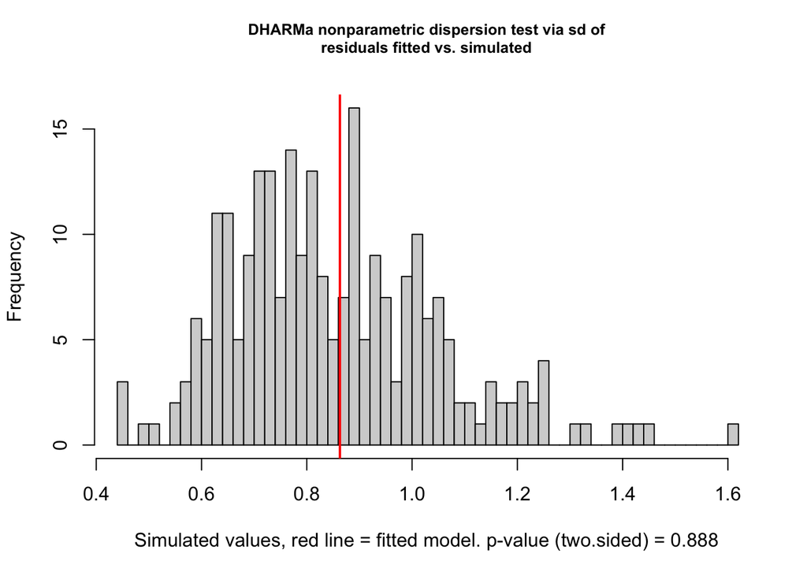

```
    DHARMa nonparametric dispersion test via sd of residuals fitted vs.
    simulated

data:  simulationOutput
dispersion = 1.0117, p-value = 0.888
alternative hypothesis: two.sided
```

```r
testDispersion(sim_res)
```

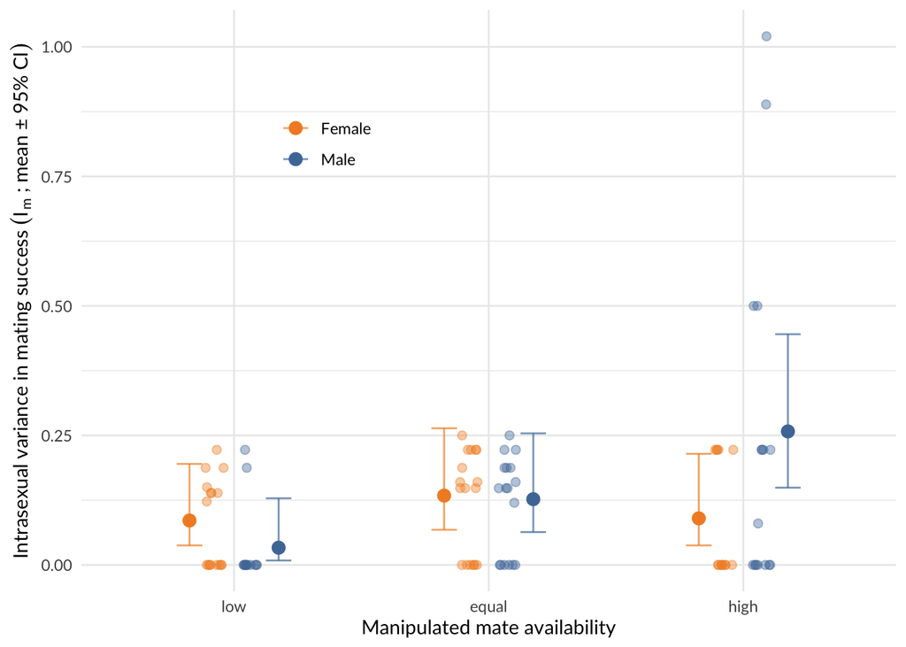

```r
# Get predictions on the link scale (default)
pred_link <-
  ggpredict(mod_tweedie_ma, terms = c("sex", "mate_availabilty")) %>%
  mutate(mate_availabilty = factor(group,
                                   levels = c("low", "equal", "high")),
         sex = factor(x, levels = c("F", "M"))) %>%
  filter(!is.na(mate_availabilty))

# plot predicted effect sizes along with raw data
ggplot() +
  # Raw data
  geom_jitter(
    data = I_m_cage_long %>% mutate(mate_availabilty = factor(mate_availabilty,
                                   levels = c("low", "equal", "high"))),
    aes(x = mate_availabilty, y = I_m, color = sex),
     position = position_jitterdodge(jitter.width = 0.15, dodge.width = 0.3),
    alpha = 0.4, size = 2
  ) +

  # Model predictions (points)
  geom_point(
    data = pred_link,
    aes(x = mate_availabilty, y = predicted, color = sex),
    position = position_dodge(width = 0.7),
    size = 3
  ) +

  # Prediction intervals (error bars)
  geom_errorbar(
    data = pred_link,
    aes(x = mate_availabilty, y = predicted, color = sex,
        ymin = conf.low, ymax = conf.high),
    position = position_dodge(width = 0.7),
    width = 0.2, alpha = 0.7
  ) +

  labs(
    x = "Manipulated mate availability",
    y = expression(Intrasexual~variance~"in"~mating~success~(italic(I)[m]~";"~mean~"\u00B1"~"95%"~CI)),
    color = "Sex", fill = "Sex"
  ) +
  theme_minimal() +
  theme(legend.position = c(0.3, 0.77),
        legend.title = element_blank(),
        text = element_text(family = "Lato")) +
  scale_fill_manual(values = c("#F28E2B", "#4E79A7"),
  labels = c("Female", "Male")) +
  scale_color_manual(values = c("#F28E2B", "#4E79A7"),
  labels = c("Female", "Male"))
```